# Homework

By 18052

2018

## Question

Use knitr to produce at least 3 examples (texts, figures, tables)

## Answer

```r
ctl <- c(4.17,5.58,5.18,6.11,4.50,4.61,5.17,4.53,5.33,5.14)
trt <- c(4.81,4.17,4.41,3.59,5.87,3.83,6.03,4.89,4.32,4.69)
group <- gl(2, 10, 20, labels = c("Ctl","Trt"))
weight <- c(ctl, trt)
lm.D9 <- lm(weight ~ group)
summary(lm.D9)$coef
```

```
##             Estimate Std. Error  t value     Pr(>|t|)
## (Intercept)    5.032  0.2202177 22.85012 9.547128e-15
## groupTrt      -0.371  0.3114349 -1.19126 2.490232e-01
```

```r
knitr::kable(head(iris))
```

| Sepal.Length | Sepal.Width | Petal.Length | Petal.Width | Species |
| --- | --- | --- | --- | --- |
| 5.1 | 3.5 | 1.4 | 0.2 | setosa |
| 4.9 | 3.0 | 1.4 | 0.2 | setosa |
| 4.7 | 3.2 | 1.3 | 0.2 | setosa |
| 4.6 | 3.1 | 1.5 | 0.2 | setosa |
| 5.0 | 3.6 | 1.4 | 0.2 | setosa |
| 5.4 | 3.9 | 1.7 | 0.4 | setosa |

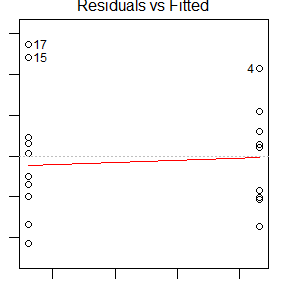

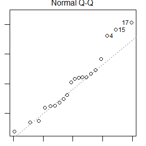

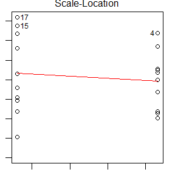

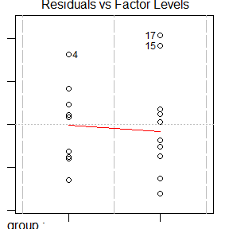

```r
par(mar=c(1,1,1,1))
plot(lm.D9)
```

##Exercise 3.4 Develop an algorithm to generate random samples from a Rayleigh(deta) distribution.Generate Rayleigh(deta) samples for several choices of deta > 0 and check that the mode of the generated samples is close to the theoretical mode ??(check the histogram).

## Answer

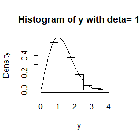

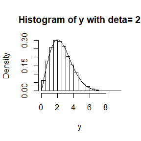

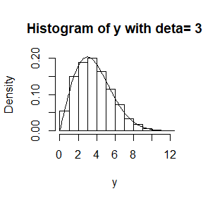

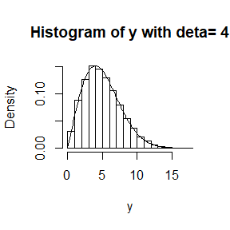

```r
n<-1e4
for (deta in 1:4) {
   x1<-rnorm(n,0,1)
   x2<-rnorm(n,0,1)
   y<-deta*sqrt(x1^2+x2^2)
   hist(y,freq = F,main=paste("Histogram of y with deta=",deta))
   z<-seq(0,15,.1)
   lines(z,(z/deta^2)*exp((-z^2)/(2*deta^2)))
}
```

##Exercise 3.11 Generate a random sample of size 1000 from a normal location mixture. The components of the mixture have N(0, 1) and N(3, 1) distributions with mixing probabilities p1 and p2 = 1 ??? p1. Graph the histogram of the sample with density superimposed, for p1 = 0.75. Repeat with different values for p1 and observe whether the empirical distribution of the mixture appears to be bimodal. Make a conjecture about the values of p1 that produce bimodal mixtures.

## Answer

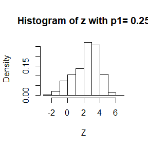

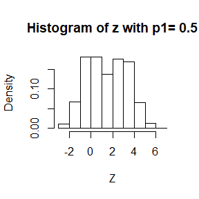

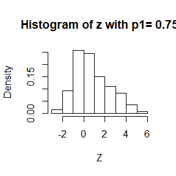

```r
n <- 1e3
X1 <- rnorm(n,0,1)
X2 <- rnorm(n,3,1)
for (p in c(0.25,0.5,0.75)) {
  r <- sample(c(1,0),n,replace=TRUE,prob = c(p,1-p))
  Z <- r*X1+(1-r)*X2
  hist(Z,freq = F,main=paste("Histogram of z with p1=",p))
}
```

According to the histograms,when p1=0.5 the mixture will be bimodal

## Exercise 3.18

Write a function to generate a random sample from a Wd(V, n) (Wishart) distribution for n > d+ 1 ??? 1, based on Bartlett???s decomposition.

## Answer

Suppose n=10,d=8 and the scale matirx V is a unit matrix for simplify

```r
n<-10
d<-8
A<-matrix(nrow=d,ncol=d)
for (i in 1:d){
  A[i,i]<-rchisq(1,n-i+1)
  j<-i+1
 while (j<=d){
   A[i,j]=0
   j=j+1
 }
  k=i-1
 while (k<i&&k>0) {
   A[i,k]<-rnorm(1,0,1)
   k=k-1
  }
}
V<-matrix(nrow = d,ncol = d)
for (i in 1:d) {
  for (j in 1:d) {
    if(i==j){V[i,j]=1}
    else V[i,j]=0
  }
}
L<-chol(V)
X<-(L%*%A)%*%t(L%*%A)
```

## Exercise 5.1

Compute a Monte Carlo estimate of
$$\int_{0}^{\pi / 3} \sin t d t$$
and compare your estimate with the exact value of the integral.

## Answer

```r
set.seed(12345)
m<-1e4
x<-runif(m,min = 0,max = pi/3)
theta.hat<-mean(sin(x))*3/pi
print(c(theta.hat,1-cos(pi/3)))
```

```
## [1] 0.4567774 0.5000000
```

## Exercise 5.10

Use Monte Carlo integration with antithetic variables to estimate
$$\int_{0}^{1} \frac{e^{-x}}{1+x^{2}} d x$$
and find the approximate reduction in variance as a percentage of the variance without variance reduction.

## Answer

```r
set.seed(12345)
m<-1e4
k<-10
r<-m/k
n<-50
T<-numeric(k)
est<-matrix(0, n, 2)
g<-function(x)exp(-x)/(1+x^2)*(x>0)*(x<1)
for (i in 1:n) {
est[i, 1] <- mean(g(runif(m)))
for(j in 1:k)T[j]<-mean(g(runif(r,(j-1)/k,j/k)))
est[i, 2] <- mean(T)
}
SD<-as.array(apply(est,2,sd))
knitr::kable(rbind(apply(est,2,mean),apply(est,2,sd)),format = 'html')
```

| 0.5250557 | 0.5247894 |
| --- | --- |
| 0.0023115 | 0.0002163 |

```r
print((SD[1]-SD[2])/SD[1])
```

```
## [1] 0.906426
```

## Exercise 5.15

Obtain the stratified importance sampling estimate in Example 5.13 and compare it with the result of Example 5.10.

## Answer

```r
set.seed(12345)
m<-1e4
k<-5
r<-m/k
n<-100
T<-numeric(k)
est<-matrix(0, n, 2)
g<-function(x)exp(-x)/(1+x^2)*(x>0)*(x<1)
for (i in 1:n) {
  u<-runif(m)
  x<- -log(1-u*(1-exp(-1)))
  fg<-g(x)/(exp(-x)/(1-exp(-1)))
  est[i, 1] <- mean(fg)
  for(j in 1:k){
    u<-runif(r,(j-1)/k,j/k)
    z<- -log(1-(u*(1-exp(-1)))/5)
    fg1<-g(z)/((5*(exp(-z))/(1-exp(-1))))
    T[j]<-mean(fg1)
    }
  est[i, 2]<-sum(T)
}
knitr::kable(rbind(apply(est,2,mean),apply(est,2,sd)),format='html')
```

| 0.5247505 | 0.6284408 |
| --- | --- |
| 0.0008807 | 0.0000080 |

## Exercise 6.5

Suppose a $95\%$ symmetric t-interval is applied to estimate a mean, but the sample data are non-normal. Then the probability that the confidence interval covers the mean is not necessarily equal to $0.95$. Use aMonte Carlo experiment to estimate the coverage probability of the t-interval for random samples of $x^2$(2) data with sample size $n = 20$. Compare your t-interval results with the simulation results in Example 6.4. (The t-interval should be more robust to departures from normality than the interval for variance.)

## Answer

```r
n<-20
m<-1e4
set.seed(1234)
mean.hat<-t.val<-numeric(m)
for (i in 1:m) {
  x<-rnorm(1)
  y<-rchisq(20,2)
  mean.hat[i]<-abs(x/sqrt(mean(y)))
  t.val[i]<-qt(0.975,40)
}
print(mean(mean.hat<=t.val))
```

```
## [1] 0.9929
```

## Exercise 6.6

Estimate the $0.025$, $0.05$, $0.95$, and $0.975$ quantiles of the skewness $\sqrt{b_{1}}$ under normality by a Monte Carlo experiment. Compute the standard error of the estimates from (2.14) using the normal approximation for the density (with exact variance formula). Compare the estimated quantiles with the quantiles of the large sample approximation $\sqrt{b_{1}} \approx N(0,6 / n)$.

## Answer

```r
n<-1e3
m<-1e4
set.seed(1234)
ske<-numeric(m)
for (i in 1:m) {
  x<-rnorm(n)
  ske[i]<-(mean((x-mean(x))^3))/(mean((x-mean(x))^2))^(3/2)
}
est<-quantile(ske,prob=c(0.025,0.05,0.95,0.975))
j=1
cv<-Var<-numeric(4)
for (p in c(0.025,0.05,0.95,0.975)) {
  cv[j] <- qnorm(p, 0, sqrt(6/n))
  Var[j]<-(p*(1-p))/n*(dnorm(est[j],0,sqrt(6/n))^2)
  j=j+1
}
res.compare<-data.frame(est,cv,Var)
knitr::kable(res.compare)
```

|  | est | cv | Var |
| --- | --- | --- | --- |
| 2.5% | -0.1544588 | -0.1518182 | 1.21e-05 |
| 5% | -0.1281055 | -0.1274098 | 8.18e-05 |
| 95% | 0.1269759 | 0.1274098 | 8.58e-05 |
| 97.5% | 0.1499843 | 0.1518182 | 1.52e-05 |

## Exercise 6.7

Estimate the power of the skewness test of normality against symmetric Beta(??, ??) distributions and comment on the results. Are the results different for heavy-tailed symmetric alternatives such as t(??)?

## Answer

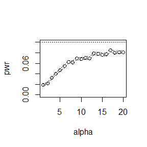

```r
beta<-0.1
n <- 20
m <- 1e4
set.seed(1234)
epsilon <- c(seq(1,20,1))
N <- length(epsilon)
pwr <- numeric(N)
cv <- qnorm(1-beta/2, 0, sqrt(6*(n-2) / ((n+1)*(n+3))))
sk <- function(x) {
  xbar <- mean(x)
  m3 <- mean((x - xbar)^3)
  m2 <- mean((x - xbar)^2)
return( m3 / m2^1.5 )
}
for (j in 1:N) {
  e <- epsilon[j]
  sktests <- numeric(m)
  for (i in 1:m) {
    x<-rbeta(n,e,e)
    sktests[i] <- as.integer(abs(sk(x)) >= cv)
  }
  pwr[j] <- mean(sktests)
}
plot(epsilon, pwr, type='b',xlab = 'alpha', ylim = c(0,.1))
abline(h = .1, lty = 3)
se <- sqrt(pwr * (1-pwr) / m)
lines(epsilon, pwr+se, lty = 3)
lines(epsilon, pwr-se, lty = 3)
```

## (i)

```r
n <- 100
alpha <- 0.1
mu0 <- 1
m <- 1e4
set.seed(1234)
p <- numeric(m)
for (i in 1:m) {
  x <- rchisq(n, mu0)
  ttest <- t.test(x, alternative = "two.sided", mu = mu0)
  p[i] <- ttest$p.value
}

p.hat <- mean(p<alpha)
se.hat <- sqrt(p.hat*(1-p.hat)/m)
print(c(p.hat, se.hat))
```

```
## [1] 0.110900000 0.003140083
```

## (ii)

```r
n <- 100
alpha <- 0.1
mu0 <- 1
m <- 1e4
set.seed(1234)
p <- numeric(m)
for (i in 1:m) {
  x <- runif(n,0,2)
  ttest <- t.test(x, alternative = "two.sided", mu = mu0)
  p[i] <- ttest$p.value
}
p.hat <- mean(p<alpha)
se.hat <- sqrt(p.hat*(1-p.hat)/m)
print(c(p.hat, se.hat))
```

```
## [1] 0.096500000 0.002952757
```

## (iii)

```r
n <- 100
alpha <- 0.1
mu0 <- 1
m <-1e4
set.seed(1234)
p <- numeric(m)
for (i in 1:m) {
  x <- rexp(n)
  ttest <- t.test(x, alternative = "two.sided", mu = mu0)
  p[i] <- ttest$p.value
}

p.hat <- mean(p<alpha)
se.hat <- sqrt(p.hat*(1-p.hat)/m)
print(c(p.hat, se.hat))
```

```
## [1] 0.106500000 0.003084765
```

## Exercise 7.6

Efron and Tibshirani discuss the scor (bootstrap) test score data on 88 students who took examinations in five subjects. The first two tests (mechanics, vectors) were closed book and the last three tests (algebra, analysis, statistics) were open book. Each row of the data frame is a set of scores $(x_{i1},...x_{i5})$ for the $i^{th}$ student. Use a panel display to display the scatter plots for each pair of test scores. Compare the plot with the sample correlation matrix. Obtain bootstrap estimates of the standard errors for each of the following estimates: $\hat\rho_{12}=\hat\rho(mec,vec),\hat \rho_{34}=\hat\rho(alg,ana), \hat\rho_{35}=\hat\rho(alg,sta), \hat\rho_{45}=\hat\rho(ana,sta)$

## Answer

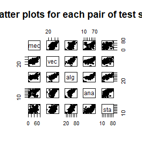

```r
set.seed(12345)
library(bootstrap)
library(boot)
scor = data.matrix(scor)
pairs(scor, main='the scatter plots for each pair of test scores', pch = 18)
```

```r
b.cor = function(x,i){
  r = cor(x[i,])
  c(r[1,2], r[3,4], r[3,5], r[4,5])
}
sc.boot = boot(data = scor, statistic = b.cor, R=2000)
apply(sc.boot$t, 2, FUN = sd)
```

```
## [1] 0.07541099 0.04809229 0.05946098 0.06825457
```

## 7.B

Repeat Project 7.A for the sample skewness statistic. Compare the coverage rates for normal populations (skewness 0) and $\chi^2(5)$ distributions (positive skewness $\sqrt\frac8 5$).

$Empirical\ coverage\ rates:\ P(CI[1]<=skew<=CI[2])$ $Proportion\ miss\ on\ the\ left:\ P(skew<CI[1])$ $Proportion\ miss\ on\ the\ right:\ P(skew>CI[2])$

## Answer

```r
set.seed(12345)
library(boot)
# normal
skew = 0
sk = function(x,i) {
  xbar = mean(x[i])
  m3 = mean((x[i] - xbar)^3)
  m2 = mean((x[i] - xbar)^2)
  return( m3 / m2^1.5 )
}
n=10
m=1000
ci.norm = ci.basic = ci.perc = matrix(0,m,2)

for(i in 1:m){
 x = rnorm(n)
 b = boot(data = x, statistic = sk, R = 2000)
 ci = boot.ci(b, type=c("norm","basic","perc"))
 ci.norm[i,] = ci$norm[2:3]
 ci.basic[i,] = ci$basic[4:5]
 ci.perc[i,] = ci$percent[4:5]
}
# output
output1 = output2 = output3 = matrix(0,2,3)
rownames(output1)=rownames(output2)=rownames(output3)=c("N(0,1)","X^2(5)")
colnames(output1)=colnames(output2)=colnames(output3)=c("norm","basic","perc")

output1[1,] = c(mean(ci.norm[,1]<=skew & ci.norm[,2]>=skew), mean(ci.basic[,1]<=skew & ci.basic[,2]>=skew), mean(ci.perc[,1]<=skew & ci.perc[,2]>=skew))
output2[1,] = c(mean(ci.norm[,1]>skew), mean(ci.basic[,1]>skew), mean(ci.perc[,1]>skew))
output3[1,] = c(mean(ci.norm[,2]<skew), mean(ci.basic[,2]<skew), mean(ci.perc[,2]<skew))
# chi-square
skew = sqrt(8/5)
ci.norm = ci.basic = ci.perc = matrix(0,m,2)
for(i in 1:m){
 x = rchisq(n,5)
 b = boot(data = x, statistic = sk, R = 2000)
 ci = boot.ci(b, type=c("norm","basic","perc"))
 ci.norm[i,] = ci$norm[2:3]
 ci.basic[i,] = ci$basic[4:5]
 ci.perc[i,] = ci$percent[4:5]
}
# output
output1[2,] = c(mean(ci.norm[,1]<=skew & ci.norm[,2]>=skew), mean(ci.basic[,1]<=skew & ci.basic[,2]>=skew), mean(ci.perc[,1]<=skew & ci.perc[,2]>=skew))
output2[2,] = c(mean(ci.norm[,1]>skew), mean(ci.basic[,1]>skew), mean(ci.perc[,1]>skew))
output3[2,] = c(mean(ci.norm[,2]<skew), mean(ci.basic[,2]<skew), mean(ci.perc[,2]<skew))
output1
```

```
##         norm basic  perc
## N(0,1) 0.899 0.887 1.000
## X^2(5) 0.755 0.741 0.736
```

```r
output2
```

```
##         norm basic perc
## N(0,1) 0.049 0.057    0
## X^2(5) 0.010 0.033    0
```

```r
output3
```

```
##         norm basic  perc
## N(0,1) 0.052 0.056 0.000
## X^2(5) 0.235 0.226 0.264
```

# Exercise 7.8

Refer to Exercise $7.7 .$ Obtain the jackknife estimates of bias and standard error of $\hat{\theta} .$

## Exercise 7.7

Refer to Exercise $7.6 .$ Efron and Tibshirani discuss the following example $[84,$$\mathrm{Ch.} 7] .$ The five-dimensional scores data have a $5 \times 5$ covariance matrix $\Sigma$,with positive eigenvalues $\lambda_{1}>\cdots>\lambda_{5} .$ In principal components analysis,
$$\theta=\frac{\lambda_{1}}{\sum_{j=1}^{5} \lambda_{j}}$$
measures the proportion of variance explained by the first principal component. Let $\hat{\lambda}_{1}>\cdots>\hat{\lambda}_{5}$ be the eigenvalues of $\hat{\Sigma},$ where $\hat{\Sigma}$ is the MLE of $\Sigma$.Compute the sample estimate of $\theta .$ Use bootstrap to estimate the bias and standard error of $\hat{\theta}$
$$\hat{\theta}=\frac{\hat{\lambda}_{1}}{\sum_{j=1}^{5} \hat{\lambda}_{j}}$$

## Answer

```r
data(scor, package = "bootstrap")
n<-nrow(scor)
f<-function(x){
  mat<-cov(x)
  evals<-eigen(mat)$values
  return(evals[1]/sum(evals))
}
theta.hat<-f(scor)
theta.jack<-numeric(n)
for (i in 1:n) {
  theta.jack[i]=f(scor[-i,])
}
bias<-(n-1)*(mean(theta.jack)-theta.hat)
print(bias)
```

```
## [1] 0.001069139
```

```r
se <- sqrt((n-1)*mean((theta.jack - mean(theta.jack))^2))
print(se)
```

```
## [1] 0.04955231
```

## Exercise 7.10

In Example $7.18,$ leave-one-out $(n$ -fold) cross validation was used to select the best fitting model. Repeat the analysis replacing the Log-Log model with a cubic polynomial model. Which of the four models is selected by the cross validation procedure? Which model is selected according to maximum adjusted $R^{2} ?$

## Answer

```r
library(DAAG)
attach(ironslag)
n <- length(magnetic)
e1 <- e2 <- e3 <- e4 <- numeric(n)
for (k in 1:n) {
  y <- magnetic[-k]
  x <- chemical[-k]

  J1 <- lm(y ~ x)
  yhat1 <- J1$coef[1] + J1$coef[2] * chemical[k]
  e1[k] <- magnetic[k] - yhat1

  J2 <- lm(y ~ x + I(x^2))
  yhat2 <- J2$coef[1] + J2$coef[2] * chemical[k] +J2$coef[3] * chemical[k]^2
  e2[k] <- magnetic[k] - yhat2

  J3 <- lm(log(y) ~ x)
  logyhat3 <- J3$coef[1] + J3$coef[2] * chemical[k]
  yhat3 <- exp(logyhat3)
  e3[k] <- magnetic[k] - yhat3

  J4 <- lm(y ~ x + I(x^2)+I(x^3))
  yhat4 <- J4$coef[1] + J4$coef[2] * chemical[k]+J4$coef[3]*chemical[k]^2+J4$coef[4]*chemical[k]^3
  e4[k] <- magnetic[k] - yhat4
}
c(mean(e1^2), mean(e2^2), mean(e3^2), mean(e4^2))
```

```
## [1] 19.55644 17.85248 18.44188 18.17756
```

```r
summary(J1)
```

```
##
## Call:
## lm(formula = y ~ x)
##
## Residuals:
##     Min      1Q  Median      3Q     Max
## -9.5784 -2.3022 -0.0203  2.1964 11.9740
##
## Coefficients:
##             Estimate Std. Error t value Pr(>|t|)
## (Intercept)   1.7881     2.5077   0.713    0.479
## x             0.8895     0.1159   7.678 5.25e-10 ***
## ---
## Signif. codes:  0 '***' 0.001 '**' 0.01 '*' 0.05 '.' 0.1 ' ' 1
##
## Residual standard error: 4.188 on 50 degrees of freedom
## Multiple R-squared:  0.5411, Adjusted R-squared:  0.5319
## F-statistic: 58.95 on 1 and 50 DF,  p-value: 5.249e-10
```

```r
summary(J2)
```

```
##
## Call:
## lm(formula = y ~ x + I(x^2))
##
## Residuals:
##     Min      1Q  Median      3Q     Max
## -8.2243 -2.4454 -0.1374  2.2346 12.5821
##
## Coefficients:
##             Estimate Std. Error t value Pr(>|t|)
## (Intercept) 25.98525    8.75932   2.967  0.00464 **
## x           -1.52948    0.85065  -1.798  0.07834 .
## I(x^2)       0.05707    0.01991   2.867  0.00609 **
## ---
## Signif. codes:  0 '***' 0.001 '**' 0.01 '*' 0.05 '.' 0.1 ' ' 1
##
## Residual standard error: 3.915 on 49 degrees of freedom
## Multiple R-squared:  0.607,  Adjusted R-squared:  0.591
## F-statistic: 37.84 on 2 and 49 DF,  p-value: 1.154e-10
```

```r
summary(J3)
```

```
##
## Call:
## lm(formula = log(y) ~ x)
##
## Residuals:
##      Min       1Q   Median       3Q      Max
## -0.63621 -0.08603 -0.00391  0.10665  0.44188
##
## Coefficients:
##             Estimate Std. Error t value Pr(>|t|)
## (Intercept) 2.127402   0.115186  18.469  < 2e-16 ***
## x           0.040570   0.005321   7.624 6.37e-10 ***
## ---
## Signif. codes:  0 '***' 0.001 '**' 0.01 '*' 0.05 '.' 0.1 ' ' 1
##
## Residual standard error: 0.1924 on 50 degrees of freedom
## Multiple R-squared:  0.5376, Adjusted R-squared:  0.5283
## F-statistic: 58.13 on 1 and 50 DF,  p-value: 6.371e-10
```

```r
summary(J4)
```

```
##
## Call:
## lm(formula = y ~ x + I(x^2) + I(x^3))
##
## Residuals:
##     Min      1Q  Median      3Q     Max
## -8.4347 -2.0627 -0.3247  2.2127 13.1177
##
## Coefficients:
##              Estimate Std. Error t value Pr(>|t|)
## (Intercept) -2.763718  26.402670  -0.105    0.917
## x            2.908468   3.938834   0.738    0.464
## I(x^2)      -0.160916   0.189976  -0.847    0.401
## I(x^3)       0.003424   0.002968   1.154    0.254
##
## Residual standard error: 3.902 on 48 degrees of freedom
## Multiple R-squared:  0.6176, Adjusted R-squared:  0.5937
## F-statistic: 25.84 on 3 and 48 DF,  p-value: 4.264e-10
```

According to the prediction error criterion, Model 2, the quadratic model,would be the best fit for the data.

According to maximum adjusted $R^{2}$, Model 4, the cubic polynomial model,would be the best fit for the data. ##Exercise 8.3

The Count 5 test for equal variances in Section 6.4 is based on the maximum number of extreme points. Example 6.15 shows that the Count 5 criterion is not applicable for unequal sample sizes. Implement a permutation test for equal variance based on the maximum number of extreme points that applies when sample sizes are not necessarily equal.

## Answer

```r
count5<- function(x, y) {
  X <- x - mean(x)
  Y <- y - mean(y)
  outx <- sum(X > max(Y)) + sum(X < min(Y))
  outy <- sum(Y > max(X)) + sum(Y < min(X))
  return(max(c(outx, outy)))
}
set.seed(1234)
n1 <- 20
n2 <- 30
K=1:(n1+n2)
mu1 <- mu2 <- 0
sigma1 <-2
sigma2 <-1
R<-1e4
x <- rnorm(n1, mu1, sigma1)
y <- rnorm(n2, mu2, sigma2)
z<-c(x,y)
n<-length(x)
reps<-numeric(R)
t0<-count5(x,y)
for (i in 1:R) {
  k<-sample(K,size = n,replace = F)
  x1<-z[k]
  y1<-z[-k]
  reps[i]=count5(x1,y1)
}
p<-mean(c(t0,reps)>t0)
round(p,3)
```

```
## [1] 0.099
```

so We reject the null hypothesis with the 10% confidence level and consider the sample variance to be different

## Question 2

Power comparison (distance correlation test versus ball covariance test)

Model 1: $Y=X / 4+e$

Model 2: $Y=X / 4 \times e$

$X \sim N\left(0_{2}, l_{2}\right), e \sim N\left(0_{2}, l_{2}\right), X$ and $e$ are independent.

## Answer

```r
distcor.test<-function(x,y){
  dCov <- function(x, y) {
  Akl <- function(x) {
    d <- as.matrix(dist(x))
    m <- rowMeans(d); M <- mean(d)
    a <- sweep(d, 1, m); b <- sweep(a, 2, m)
    b + M
  }
A<- Akl(x); B <- Akl(y)
sqrt(mean(A * B))
}
ndCov2 <- function(z, ix, dims) {
  p <- dims[1]
  q <- dims[2]
  d <- p + q
  x <- z[ , 1:p]
  y <- z[ix, -(1:p)]
  return(nrow(z) * dCov(x, y)^2)
}
set.seed(1234)
z <-cbind(x,y)
boot.obj <- boot(data = z, statistic = ndCov2, R = 999,
sim = "permutation", dims = c(2, 2))
tb <- c(boot.obj$t0, boot.obj$t)
p.cor <- mean(tb>=tb[1])
}
```

Model 1

```r
library('MASS')
library('Ball')
library('boot')
n<-30
mu<-matrix(c(0,0),2,1)
sigma<-matrix(c(1,0,0,1),2,2)
x<-mvrnorm(n,mu,sigma)
e<-mvrnorm(n,mu,sigma)
y<-(x/4+e)
p.dist<-distcor.test(x,y)
p.ball <- bcov.test(x,y,R=999)$p.value
round(c(p.dist,p.ball),4)
```

```
##                      bcov.constant.pvalue
##                0.688                0.460
```

Model 2

```r
library('MASS')
library('Ball')
library('boot')
n<-30
mu<-matrix(c(0,0),2,1)
sigma<-matrix(c(1,0,0,1),2,2)
x<-mvrnorm(n,mu,sigma)
e<-mvrnorm(n,mu,sigma)
y<-(x/4)*e
p.dist<-distcor.test(x,y)
p.ball <- bcov.test(x,y,R=999)$p.value
round(c(p.dist,p.ball),4)
```

```
##                      bcov.constant.pvalue
##                0.013                0.010
```

## Exercise 9.4

Implement a random walk Metropolis sampler for generating the standard Laplace distribution (see Exercise 3.2). For the increment, simulate from a normal distribution. Compare the chains generated when different variances are used for the proposal distribution. Also, compute the acceptance rates of each chain.

## Answer

```r
library(GeneralizedHyperbolic)
Laplace.Metropolis<-function(sigma,N){
  x<-numeric(N)
  x[1]<-rnorm(1,0,sigma)
  u<-runif(N)
  k<-0
  for (i in 2:N) {
    y<-rnorm(1,x[i-1],sigma)
    if(u[i]<=dskewlap(y)/dskewlap(x[i-1]))
      x[i]=y
    else{
      x[i]=x[i-1]
      k=k+1
    }
  }
  return(list(x=x,k=k))
}
N<-1e4
sigma<-c(1,4,9,16)
set.seed(1234)
laplace1<-Laplace.Metropolis(sigma[1],N)
laplace2<-Laplace.Metropolis(sigma[2],N)
laplace3<-Laplace.Metropolis(sigma[3],N)
laplace4<-Laplace.Metropolis(sigma[4],N)
print(c(1-laplace1$k/N,1-laplace2$k/N,1-laplace3$k/N,1-laplace4$k/N))
```

```
## [1] 0.7018 0.3509 0.1645 0.0944
```

## Questions

### 11.1

- The natural logarithm and exponential functions are inverses of each other, so that mathematically log(exp x) = exp(log x) = x. Show by example that this property does not hold exactly in computer arithmetic. Does the identity hold with near equality? (See all.equal.)

### 11.5

- Write a function to solve the equation
  $$\frac{2 \Gamma\left(\frac{k}{2}\right)}{\sqrt{\pi(k-1) \Gamma\left(\frac{k-1}{2}\right)}} \int_{0}^{c_{k-1}}\left(1+\frac{u^{2}}{k-1}\right)^{-k / 2} d u = \frac{2 \Gamma\left(\frac{k+1}{2}\right)}{\sqrt{\pi k} \Gamma\left(\frac{k}{2}\right)} \int_{0}^{c_{k}}\left(1+\frac{u^{2}}{k}\right)^{-(k+1) / 2} d u$$
  for a, where
  $$c_{k}=\sqrt{\frac{a^{2} k}{k+1-a^{2}}}$$
  Compare the solutions with the points A(k) in Exercise 11.4.

## Answers

### 11.1

- This property does not hold exactly in computer arithmetic, but the identity holds with near equality.

```r
exp(log(20)) == log(exp(20))
```

```
## [1] FALSE
```

```r
all.equal(exp(log(20)),log(exp(20)))
```

```
## [1] TRUE
```

### 11.5

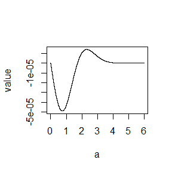

```r
gammaratio <- function(k){
  if (k %% 2==0)
    return(exp(sum(log((k/2-1):1))-sum(log(seq(1,k-3,2)/2))-log(gamma(1/2))))
  else
    return(exp(sum(log(seq(1,k-2,2)/2))+log(gamma(1/2))-sum(log(((k-1)/2-1):1))))
}   ### Gamma ratio computing for large k
g<- function(a,k){
  f <- function(x, N) (1 + x^2/N)^(-(N + 1)/2)
  I1 <- integrate(f,lower = 0,upper = sqrt(a^2*(k-1)/(k-a^2)),rel.tol=.Machine$double.eps^0.25,N = k-1 )$value
  I2 <- integrate(f,lower = 0,upper = sqrt(a^2*k/(k+1-a^2)),rel.tol=.Machine$double.eps^0.25,N = k )$value
  return(2*gammaratio(k)*I1/sqrt(k-1)-2*gammaratio(k+1)*I2/sqrt(k))
}   # the equation in 11.5
f1 <- function(x,k) pt(sqrt(x^2*(k-1)/(k-x^2)),k-1)-pt(sqrt(x^2*k/(k+1-x^2)),k)
##  computing method in 11.4
a <- seq(0.001,6,0.0001)
y1 <-numeric(length(a))
for ( i in 1:length(a)){
  y1[i] <- g(a[i],100)
}
plot(cbind(a,y1),type = "l",xlab="a",ylab = "value")
```

- We can see from the figure there is only one zero point in (0,$\sqrt{k}$).

```r
nk <- c(4:25,100,500,1000)
ak <-numeric(25)
qk <-numeric(25)
for (i in 1:25) {
  ak[i] <- uniroot(g,c(0.00001,ifelse(nk[i] <=7,sqrt(nk[i])-0.01,2.5)),k=nk[i])$root # the solution of the equation
  qk[i] <- uniroot(f1,c(0.00001,ifelse(nk[i] <=7,sqrt(nk[i])-0.01,2.5)),k=nk[i])$root # the solution of 11.4
}
cbind(ak,qk)
```

```
##             ak       qk
##  [1,] 1.492102 1.492102
##  [2,] 1.533534 1.533534
##  [3,] 1.562765 1.562765
##  [4,] 1.584427 1.584427
##  [5,] 1.601199 1.601199
##  [6,] 1.614521 1.614521
##  [7,] 1.625385 1.625385
##  [8,] 1.634409 1.634409
##  [9,] 1.642026 1.642026
## [10,] 1.648511 1.648511
## [11,] 1.654187 1.654187
## [12,] 1.659099 1.659099
## [13,] 1.663433 1.663433
## [14,] 1.667286 1.667286
## [15,] 1.670735 1.670735
## [16,] 1.673840 1.673840
## [17,] 1.676589 1.676589
## [18,] 1.679145 1.679145
## [19,] 1.681471 1.681471
## [20,] 1.683594 1.683594
## [21,] 1.685546 1.685546
## [22,] 1.687347 1.687347
## [23,] 1.720598 1.720598
## [24,] 1.729744 1.729744
## [25,] 1.730895 1.730895
```

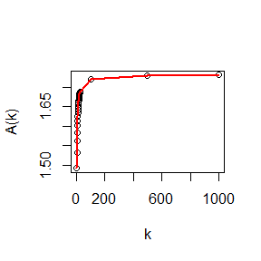

```r
plot(cbind(nk,ak),xlab = "k",ylab = "A(k)")
lines(cbind(nk,ak),lwd =2,col = "red")
```

### A-B-O blood type problem

```r
loglike <- function(pq,ng){
  p <- pq[1]
  q <- pq[2]
  r <- 1-p -q
  a <- c(p^2,q^2,r^2,2*p*r,2*q*r,2*p*q)
  return(-sum(log(a)*ng))
}
na <- 28
nb <- 24
noo <- 41
nab <- 70
n <-na + nb +noo+nab
eloglike <- function(pq){
  p <- pq[1]
  q <- pq[2]
  r <- 1-p -q
  a <- c(p^2+2*p*r,q^2+2*q*r,r^2,2*p*q)
  ng <- c(na,nb,noo,nab)
  return(-sum(log(a)*ng))
}
r <- sqrt(noo/n)
f2 <- function(x) x^2 +2*x*r - na/n
p <- uniroot(f2,c(0,1))$root
q <- 1-p-r
m <- 200
pqr <- matrix(rep(0,m*3),nrow = m)
ll <- numeric(m)
pqr[1,]<-c(p,q,r)
for (i in 2:m) {
  p <- pqr[i-1,1]
  q <- pqr[i-1,2]
  r <- pqr[i-1,3]
  naa <- p/(p+2*r)*na
  nao <- 2*r/(p+2*r)*na
  nbb <- q/(q+2*r)*nb
  nbo <- 2*r/(q+2*r)*nb
  ng <- c(naa,nbb,noo,nao,nbo,nab)  #estimation step
  res <- optim(c(p,q),loglike,method="Nelder-Mead",ng=ng) #maximum step
  pqr[i,]<-c(res$par,1-res$par[1]-res$par[2])
  ll[i] <- -eloglike(res$par)
}
```

- The final results of p,q,r

```r
pqr[200,]
```

```
## [1] 0.3272644 0.3104069 0.3623288
```

- Solving the log-likelihood directly.

```r
res <- optim(c(p,q),eloglike,method="Nelder-Mead")
res$par
```

```
## [1] 0.3274290 0.3104228
```

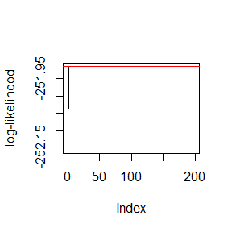

```r
plot(ll[-1],type = "l",ylab = "log-likelihood")
abline(a=ll[200],b=0,col="red")
```

- According to the figure,the log-maximum likelihood values in M-steps are increasing and converge at last. ##11.1.2 Exercise 3

Use both for loops and lapply() to fit linear models to the mtcars using the formulas stored in this list:

formulas <- list(mpg ~ disp,mpg ~ I(1 / disp),mpg ~ disp + wt,mpg ~ I(1 / disp) + wt)

## Answer

```r
formulas <- list(mpg ~ disp,mpg ~ I(1 / disp),mpg ~ disp + wt,mpg ~ I(1 / disp) + wt)
out1<-vector("list",length(formulas))
for (i in 1:length(formulas)) {
  out1[[i]]<-lm(formulas[[i]],data=mtcars)
}
out2<-lapply(formulas,lm,data=mtcars)
out1
```

```
## [[1]]
##
## Call:
## lm(formula = formulas[[i]], data = mtcars)
##
## Coefficients:
## (Intercept)         disp
##    29.59985     -0.04122
##
##
## [[2]]
##
## Call:
## lm(formula = formulas[[i]], data = mtcars)
##
## Coefficients:
## (Intercept)    I(1/disp)
##       10.75      1557.67
##
##
## [[3]]
##
## Call:
## lm(formula = formulas[[i]], data = mtcars)
##
## Coefficients:
## (Intercept)         disp           wt
##    34.96055     -0.01772     -3.35083
##
##
## [[4]]
##
## Call:
## lm(formula = formulas[[i]], data = mtcars)
##
## Coefficients:
## (Intercept)    I(1/disp)           wt
##      19.024     1142.560       -1.798
```

## 11.1.2 Exercise 4

Fit the model mpg ~ disp to each of the bootstrap replicates of mtcars in the list below by using a for loop and lapply(). Can you do it without an anonymous function?

bootstraps <- lapply(1:10, function(i) { rows <- sample(1:nrow(mtcars), rep = TRUE) mtcars[rows, ] })

## Answer

```r
bootstraps<-lapply(1:10, function(i) {
  rows <- sample(1:nrow(mtcars), rep = TRUE)
  mtcars[rows, ]
  }
)
out3<-vector("list",10)
for (i in 1:10) {
  out3[[i]]<-lm(mpg~disp,data=bootstraps[[i]])
}
out4<-lapply(bootstraps,lm,formula=mpg~disp)
out3
```

```
## [[1]]
##
## Call:
## lm(formula = mpg ~ disp, data = bootstraps[[i]])
##
## Coefficients:
## (Intercept)         disp
##     26.4690      -0.0308
##
##
## [[2]]
##
## Call:
## lm(formula = mpg ~ disp, data = bootstraps[[i]])
##
## Coefficients:
## (Intercept)         disp
##    29.82463     -0.03682
##
##
## [[3]]
##
## Call:
## lm(formula = mpg ~ disp, data = bootstraps[[i]])
##
## Coefficients:
## (Intercept)         disp
##    29.06104     -0.03814
##
##
## [[4]]
##
## Call:
## lm(formula = mpg ~ disp, data = bootstraps[[i]])
##
## Coefficients:
## (Intercept)         disp
##    28.57694     -0.03535
##
##
```

[output cut: 43 more lines]

```
## lm(formula = mpg ~ disp, data = bootstraps[[i]])
##
## Coefficients:
## (Intercept)         disp
##    28.68740     -0.03716
##
##
## [[10]]
##
## Call:
## lm(formula = mpg ~ disp, data = bootstraps[[i]])
##
## Coefficients:
## (Intercept)         disp
##    30.67792     -0.04692
```

## 11.1.2 Exercise 5

For each model in the previous two exercises, extract R2 using the function below.

rsq <- function(mod) summary(mod)$r.squared

## Answer

```r
rsq <- function(mod) summary(mod)$r.squared
lapply(out1,rsq)
```

```
## [[1]]
## [1] 0.7183433
##
## [[2]]
## [1] 0.8596865
##
## [[3]]
## [1] 0.7809306
##
## [[4]]
## [1] 0.8838038
```

```r
lapply(out3,rsq)
```

```
## [[1]]
## [1] 0.6000521
##
## [[2]]
## [1] 0.629544
##
## [[3]]
## [1] 0.665664
##
## [[4]]
## [1] 0.6725041
##
## [[5]]
## [1] 0.7509581
##
## [[6]]
## [1] 0.7179071
##
## [[7]]
## [1] 0.6769069
##
## [[8]]
## [1] 0.7217327
##
## [[9]]
## [1] 0.6656836
##
## [[10]]
## [1] 0.8296328
```

## 11.2.5 Exercise 3

The following code simulates the performance of a t-test for non-normal data. Use sapply() and an anonymous function to extract the p-value from every trial.

trials<-replicate(100, t.test(rpois(10, 10), rpois(7, 10)), simplify = FALSE)

Extra challenge: get rid of the anonymous function by using [[ directly. ##Answer

```r
trials<-replicate(100, t.test(rpois(10, 10), rpois(7, 10)), simplify = FALSE)
p_value<-sapply(trials, function(x) x$p.value)
p_value2<-sapply(trials, '[[',3)
p_value
```

```
##   [1] 0.226234733 0.878699690 0.023636944 0.002863181 0.283263429 0.342715493
##   [7] 0.280393022 0.895401464 0.444668045 0.955958794 0.840814492 0.915422519
##  [13] 0.318264061 0.659470388 0.755335363 0.062552306 0.201374001 0.843761138
##  [19] 0.102700821 0.810551787 0.336871352 0.983426627 0.654647238 0.212360540
##  [25] 0.558590192 0.515757542 0.627910997 0.354903758 0.932726022 0.410597054
##  [31] 0.588269425 0.766716658 0.305949455 0.191648159 0.923430953 0.233832635
##  [37] 0.007715163 0.636923221 0.546470935 0.101839183 0.633595727 0.885810579
##  [43] 0.641792946 0.260437129 0.377980255 0.329324914 0.909868603 0.904938123
##  [49] 0.895475321 0.796516410 0.886190335 0.241623031 0.457651060 0.508391008
##  [55] 0.554745562 0.555530013 0.517136450 0.237152954 0.726398646 0.128271193
##  [61] 0.055546426 0.833201948 0.055684921 0.313481890 0.674045813 0.496379419
##  [67] 0.181788795 0.588977335 0.272538493 0.428096391 0.690500493 0.147715047
##  [73] 0.120305341 0.465157841 0.805365236 0.548290932 0.279067560 0.920286134
##  [79] 0.298992191 0.283991735 0.441317646 0.533652819 0.142944393 0.920812613
##  [85] 0.634335308 0.719262180 0.343715387 0.506414946 0.647267652 0.161587341
##  [91] 0.558221586 0.571337643 0.948372532 0.481177694 0.846617931 0.537704063
##  [97] 0.642115127 0.139222858 0.436743209 0.462786126
```

```r
p_value2
```

```
##   [1] 0.226234733 0.878699690 0.023636944 0.002863181 0.283263429 0.342715493
##   [7] 0.280393022 0.895401464 0.444668045 0.955958794 0.840814492 0.915422519
##  [13] 0.318264061 0.659470388 0.755335363 0.062552306 0.201374001 0.843761138
##  [19] 0.102700821 0.810551787 0.336871352 0.983426627 0.654647238 0.212360540
##  [25] 0.558590192 0.515757542 0.627910997 0.354903758 0.932726022 0.410597054
##  [31] 0.588269425 0.766716658 0.305949455 0.191648159 0.923430953 0.233832635
##  [37] 0.007715163 0.636923221 0.546470935 0.101839183 0.633595727 0.885810579
##  [43] 0.641792946 0.260437129 0.377980255 0.329324914 0.909868603 0.904938123
##  [49] 0.895475321 0.796516410 0.886190335 0.241623031 0.457651060 0.508391008
##  [55] 0.554745562 0.555530013 0.517136450 0.237152954 0.726398646 0.128271193
##  [61] 0.055546426 0.833201948 0.055684921 0.313481890 0.674045813 0.496379419
##  [67] 0.181788795 0.588977335 0.272538493 0.428096391 0.690500493 0.147715047
##  [73] 0.120305341 0.465157841 0.805365236 0.548290932 0.279067560 0.920286134
##  [79] 0.298992191 0.283991735 0.441317646 0.533652819 0.142944393 0.920812613
##  [85] 0.634335308 0.719262180 0.343715387 0.506414946 0.647267652 0.161587341
##  [91] 0.558221586 0.571337643 0.948372532 0.481177694 0.846617931 0.537704063
##  [97] 0.642115127 0.139222858 0.436743209 0.462786126
```

## 11.2.5 Exercise 7

Implement mcsapply(), a multicore version of sapply(). Can you implement mcvapply(), a parallel version of vapply()? Why or why not? ##Question

You have already written an R function for Exercise 9.4 (page 277, Statistical Computing with R). Rewrite an Rcpp function for the same task.

Compare the generated random numbers by the two functions using qqplot.

Campare the computation time of the two functions with microbenchmark.

## Answer

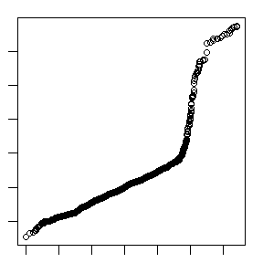

```r
library(Rcpp)
library(microbenchmark)
library(GeneralizedHyperbolic)
cppFunction('List Cpplaplace(double Sigma,int N){
  NumericVector x(N);
  int k=0;
  x[0]=as<double>(rnorm(1,25,Sigma));
  for(int i=1;i<N;i++){
    double y=as<double>(rnorm(1,x[i-1],Sigma));
    double u=as<double>(runif(1));
    if (u<=exp(-abs(y))/exp(-abs(x[i-1]))) {
    x[i]=y;
    k=k+1;
    }
    else x[i]=x[i-1];
  }
  return(List::create(Named("x")=x,Named("k")=k));
}')
Laplace.Metropolis<-function(sigma,N){
  x<-numeric(N)
  x[1]<-rnorm(1,0,sigma)
  u<-runif(N)
  k<-0
  for (i in 2:N) {
    y<-rnorm(1,x[i-1],sigma)
    if(u[i]<=dskewlap(y)/dskewlap(x[i-1])){
      x[i]=y
      k=k+1
    }
    else
      x[i]=x[i-1]
  }
  return(list(x=x,k=k))
}
N<-10000
sigma<-c(1,4,9,16)
set.seed(1234)
laplace1<-Laplace.Metropolis(sigma[1],N)
laplace2<-Laplace.Metropolis(sigma[2],N)
laplace3<-Laplace.Metropolis(sigma[3],N)
laplace4<-Laplace.Metropolis(sigma[4],N)
Claplace1<-Cpplaplace(sigma[1],N)
Claplace2<-Cpplaplace(sigma[2],N)
Claplace3<-Cpplaplace(sigma[3],N)
Claplace4<-Cpplaplace(sigma[4],N)
par(mar=c(1,1,1,1))
qqplot(laplace1$x,Claplace1$x)
```

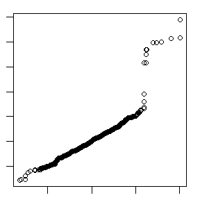

```r
qqplot(laplace2$x,Claplace2$x)
```

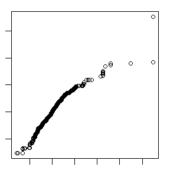

```r
qqplot(laplace3$x,Claplace3$x)
```

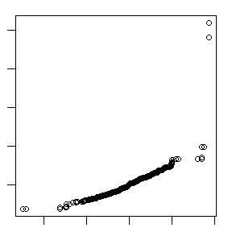

```r
qqplot(laplace4$x,Claplace4$x)
```

```r
compare1<-microbenchmark(Laplace.Metropolis(sigma[1],N),Cpplaplace(sigma[1],N))
compare2<-microbenchmark(Laplace.Metropolis(sigma[2],N),Cpplaplace(sigma[2],N))
compare3<-microbenchmark(Laplace.Metropolis(sigma[3],N),Cpplaplace(sigma[3],N))
compare4<-microbenchmark(Laplace.Metropolis(sigma[4],N),Cpplaplace(sigma[4],N))
summary(compare1)[c(1,3,5,6)]
```

```
##                              expr       lq   median        uq
## 1 Laplace.Metropolis(sigma[1], N) 95.67775 98.79155 109.72910
## 2         Cpplaplace(sigma[1], N)  2.29920  2.42545   2.77245
```

```r
summary(compare2)[c(1,3,5,6)]
```

```
##                              expr      lq   median        uq
## 1 Laplace.Metropolis(sigma[2], N) 95.3877 97.46265 101.04540
## 2         Cpplaplace(sigma[2], N)  2.3873  2.48155   2.65795
```

```r
summary(compare3)[c(1,3,5,6)]
```

```
##                              expr       lq   median       uq
## 1 Laplace.Metropolis(sigma[3], N) 95.16165 96.36275 99.12825
## 2         Cpplaplace(sigma[3], N)  2.41150  2.49730  2.65890
```

```r
summary(compare4)[c(1,3,5,6)]
```

```
##                              expr       lq  median       uq
## 1 Laplace.Metropolis(sigma[4], N) 95.37545 97.0829 101.4471
## 2         Cpplaplace(sigma[4], N)  2.38450  2.5162   2.7660
```